# Simulation-Based Statistical Inference Study

Author

Ashley Navos

```r
library(tidyverse)
library(broom)
library(knitr)
```

## Overview

This simulation-based study investigates how randomness affects matching outcomes and evaluates the coverage properties of 95% confidence intervals in linear regression. Using Monte Carlo simulations, the analysis empirically demonstrates that confidence intervals achieve near-nominal coverage under correct model assumptions, reinforcing theoretical results through repeated sampling.

## Permutation Simulation: Random Assignment Experiment

Simulation using [Random Babies applet](https://www.rossmanchance.com/applets/2021/randombabies/RandomBabies.html). Objective is to find the number of babies that are correctly returned to their respective parent(s).

**Simulating the distribution of the number of babies that are correctly returned if there were four babies born in a night at the disorganized hospital.**

```r
set.seed(123)
randomBabies <- function(n_babies){
  shuffled_babies <- sample(n_babies) #if size not given will just return length of vector
  correct <- sum(shuffled_babies == 1:n_babies) #1:n_babies is "correct" families. ex 1 3 2 4 == 1 2 3 4, T F F T
  return(correct)
}
```

```r
results <- map_int(.x = 1:10000, #repeating simulation 10,000 times
                   .f = ~ randomBabies(4)
                  )
```

**Table that displays the proportion of simulations where 0, 1, 2, 3, and 4 babies were given to their correct parent(s).**

```r
prop_returned <- enframe(results, name = "simulation", value = "correct_babies_returned") |>
  count(correct_babies_returned) |> # occurrences of each amount of babies correctly returned (n), collapses
  mutate(prop = n / sum(n)) |> #sum(n) gives total anyways
  select(-n)

prop_returned |>
  kable()
```

| correct_babies_returned | prop |
| --- | --- |
| 0 | 0.3737 |
| 1 | 0.3386 |
| 2 | 0.2465 |
| 4 | 0.0412 |

**Barplot showing the proportion of simulations where 0, 1, 2, 3, and 4 babies were given to their correct parent(s).**

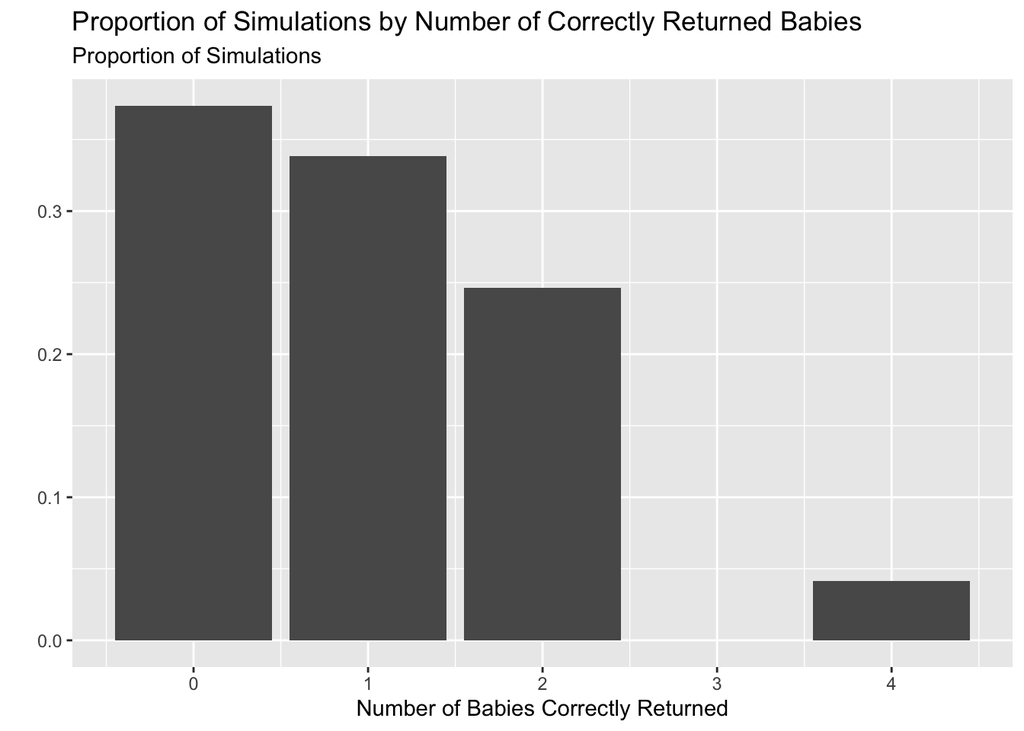

```r
prop_returned |>
  ggplot(aes(x = correct_babies_returned, y = prop)) +
  geom_bar(stat = "identity") +
  labs(x = "Number of Babies Correctly Returned",
       y = "",
       subtitle = "Proportion of Simulations",
       title = "Proportion of Simulations by Number of Correctly Returned Babies")
```

## Simulating Coverage

**Generating a synthetic uniform dataset with 100 observations.**

```r
# define slope and intercept parameters
intercept = 2
slope = 1

# generate x vector
x <- runif(100)

# generate noise `ep` vector
ep <- rnorm(100)

# generate outcome from population model
y = intercept + x*slope + ep

# create an "observed data" dataframe with only the x and y vectors
observed_data <- data.frame(x = x, y = y)
```

**Linear Regression on Synthetic Dataset**

```r
linear_reg <- lm(y ~ x, data = observed_data)

kable(tidy(linear_reg, conf.int=TRUE))
```

| term | estimate | std.error | statistic | p.value | conf.low | conf.high |
| --- | --- | --- | --- | --- | --- | --- |
| (Intercept) | 2.2061017 | 0.1934368 | 11.404766 | 0.0000000 | 1.8222326 | 2.589971 |
| x | 0.7899116 | 0.3270194 | 2.415489 | 0.0175673 | 0.1409523 | 1.438871 |

**True population slope is inside of the estimated 95% confidence interval for the simulated dataset. The variable `cover` is `1` if the population slope is in the interval and `0` if not.**

```r
linear_reg_summary <- tidy(linear_reg, conf.int = TRUE) |>
  mutate(cover = if_else(slope >= conf.low & slope <= conf.high, 1, 0))

kable(linear_reg_summary)
```

| term | estimate | std.error | statistic | p.value | conf.low | conf.high | cover |
| --- | --- | --- | --- | --- | --- | --- | --- |
| (Intercept) | 2.2061017 | 0.1934368 | 11.404766 | 0.0000000 | 1.8222326 | 2.589971 | 0 |
| x | 0.7899116 | 0.3270194 | 2.415489 | 0.0175673 | 0.1409523 | 1.438871 | 1 |

**Previous 3 steps combined into a function called `mycifun`**

```r
mycifun <- function(beta0, beta1, n){

  # generate x vector
  x <- runif(n)

  # generate noise `ep` vector
  ep <- rnorm(n)

  # generate outcome from population model
  y = beta0 + x*beta1 + ep

  # create an "observed data" dataframe with only the x and y vectors
  observed_data <- data.frame(x = x, y = y)

  # fitting a linear model
  linear_reg <- lm(y ~ x, data = observed_data)

  # determining coverage
  linear_reg_summary <- tidy(linear_reg, conf.int = TRUE) |>
  filter(term == "x") |>
  mutate(cover = if_else(beta1 >= conf.low & beta1 <= conf.high, 1, 0))

  return(linear_reg_summary)
}
```

```r
mycifun(beta0 = 1, beta1 = 2, n = 1000) |>
  kable()
```

| term | estimate | std.error | statistic | p.value | conf.low | conf.high | cover |
| --- | --- | --- | --- | --- | --- | --- | --- |
| x | 1.857981 | 0.1121247 | 16.57067 | 0 | 1.637954 | 2.078009 | 1 |

**Running simulation 1,000 times. Generating data with** $\beta_0 = 3$, $\beta_1 = .5$ and $n = 100$.

```r
set.seed(123)
ci_dat <- map_dfr(.x = 1:1000,
                  .f = ~ mycifun(3, .5, 100)
                    )
```

**Simulated coverage rate is** 0.953

```r
ci_dat |>
  summarize(coverage_rate = mean(cover)) |>
  kable()
```

| coverage_rate |
| --- |
| 0.953 |

**Visualization illustrating coverage rate.**

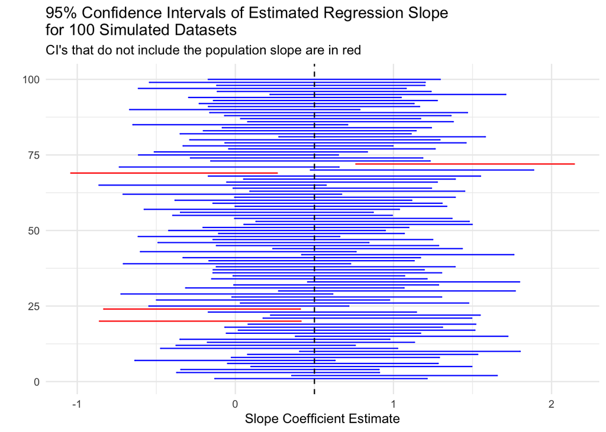

```r
set.seed(123)
ci_sample <- sample_n(ci_dat, 100) |> #taking random sample of 100
  filter(term == "x") |>
  mutate(sim_id = row_number())  # in order to have a y-position

ggplot(ci_sample, aes(x = estimate, y = sim_id)) +
  geom_errorbarh(aes(xmin = conf.low, xmax = conf.high, color = factor(cover)), height = 0.4) +
  geom_vline(xintercept = 0.5, linetype = "dashed", color = "black") +
  scale_color_manual(values = c("0" = "red", "1" = "blue")) +
  labs(
    title = "95% Confidence Intervals of Estimated Regression Slope \nfor 100 Simulated Datasets",
    subtitle = "CI's that do not include the population slope are in red",
    x = "Slope Coefficient Estimate",
    y = "",
    color = NULL
  ) +
  theme_minimal() +
  theme(legend.position = "none")
```

## Conclusions

- Random permutation simulations demonstrate that perfect matching is rare, with most outcomes resulting in zero or one correct assignment.
- Simulation-based confidence interval coverage for linear regression slopes converges to the nominal 95% level across repeated samples.
- These results validate theoretical properties of confidence intervals and illustrate the value of simulation for understanding statistical inference.